# Bolt Test Assignment: 2 question

Gadir Mamedov

## 0.1 Introduction

This document attempts to solve the following task.

- Provide a formal definition for “TPR”. Analyse market health, provide insights and conclusions.

## 0.2 Tickets Per Ride (TPR) and Summary

> **Tickets Per Ride** is a measure indicating a ratio of incoming tickets to all completed rides.

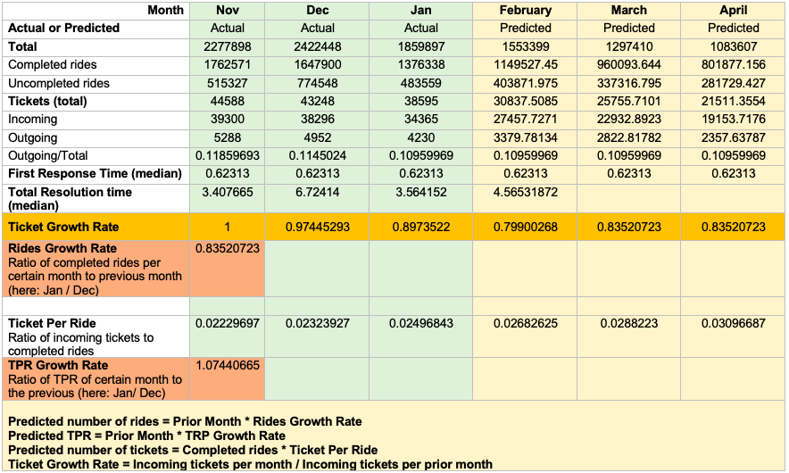

This table was done in the first part of assignment and shows calculations of TPR for both actual and predicted months. As we see, number of tickets composes around **2-3%** of total rides.

It is a bad sign that, despite the decrease in number of tickets, ratio of tickets to rides (TPR) slightly increases. And TPR Growth Rate demonstrates that there should be optimization of customer support service in place.

## 0.3 General overview of market

```r
summary(orders)
```

```
    created                          id            completed          rider_id
 Min.   :2019-11-01 00:00:00   Min.   :6.408e+14   Mode :logical   Min.   :1.072e+15
 1st Qu.:2019-11-22 23:24:28   1st Qu.:8.151e+17   FALSE:1773434   1st Qu.:8.161e+17
 Median :2019-12-13 14:37:19   Median :1.153e+18   TRUE :4786809   Median :1.153e+18
 Mean   :2019-12-14 11:46:12   Mean   :1.153e+18                   Mean   :1.154e+18
 3rd Qu.:2020-01-04 13:20:43   3rd Qu.:1.490e+18                   3rd Qu.:1.492e+18
 Max.   :2020-01-31 00:00:00   Max.   :2.306e+18                   Max.   :2.304e+18
                                                                   NA's   :1
   driver_id             rating        ride_distance          date            wdays
 Min.   :1.479e+16   Min.   :0         Min.   :      0   Min.   :2019-11-01   Sun: 911711
 1st Qu.:8.237e+17   1st Qu.:5         1st Qu.:   3301   1st Qu.:2019-11-22   Mon: 747239
 Median :1.154e+18   Median :5         Median :   5591   Median :2019-12-13   Tue: 795350
 Mean   :1.160e+18   Mean   :5         Mean   :   7250   Mean   :2019-12-13   Wed: 846662
 3rd Qu.:1.493e+18   3rd Qu.:5         3rd Qu.:   9263   3rd Qu.:2020-01-04   Thu: 871435
 Max.   :2.303e+18   Max.   :5         Max.   :1514684   Max.   :2020-01-31   Fri:1167874
 NA's   :327568      NA's   :4791741   NA's   :1783515                        Sat:1219972
      mday           month              timeday            hours          monthnum
 Min.   : 1.00   Dec    :2422448   Night    :1333682   Min.   : 0.00   Min.   : 1.000
 1st Qu.: 8.00   Nov    :2277898   Morning  :1584881   1st Qu.: 8.00   1st Qu.: 1.000
 Median :15.00   Jan    :1859897   Afternoon:1970304   Median :14.00   Median :11.000
 Mean   :15.56   Feb    :      0   Evening  :1671376   Mean   :12.91   Mean   : 8.534
 3rd Qu.:23.00   Mar    :      0                       3rd Qu.:19.00   3rd Qu.:12.000
 Max.   :31.00   Apr    :      0                       Max.   :23.00   Max.   :12.000
                 (Other):      0
```

Another interesting information relates to ride distance. As may seen from summary, median amount of km is equal to 5.5. So, ride averages to 5.5 km, while 75% of all cases are not more than 9 km. However, there are clear outliers in the dataset that much higher than 9 km. For example, maximum number is around 1514 km. At the same time, dataset lacks data on 1.7 million rides.

## 0.4 Visualization

### 0.4.1 Completed and uncompleted rides

```
NA
```

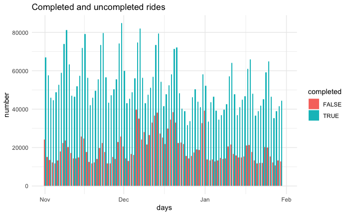

Visually, amount of rides gradually decreases by February. Although, the level of uncompleted rides is waving, there is a stark increase in December. And despite the fact that number of rides falls, number of uncompleted rides seems to stay at the same level.

### 0.4.2 How many unique users and drivers there? (not counting NAs)

> Unique drivers number = 24911 Unique riders number = 869596

## 0.5 Statistics

### 0.5.1 When rides get cancelled most?

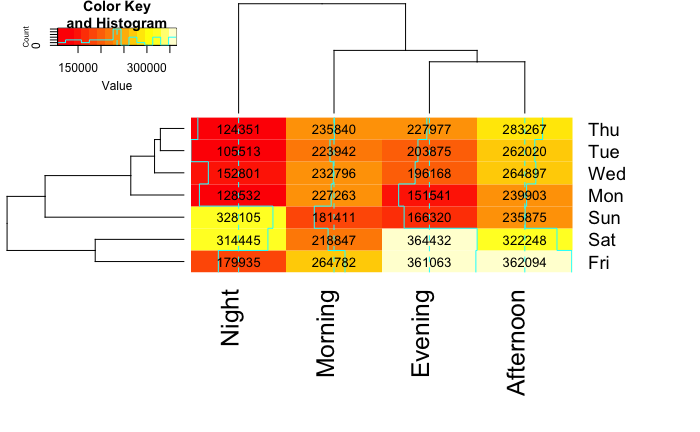

### 0.5.2 Rides and hours

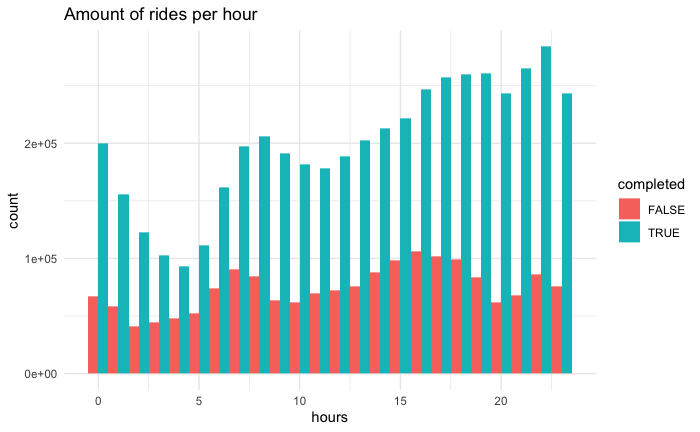

Amount of rides increases gradually from morning to night with slight fall during lunch hours. The same is correct for non-completed rides; although, their picks are in the monring and around 3 and 6 pm.

### 0.5.3 Bad ratings?

```
[1] 0.04479133
```

Considering that ratings less than 5 constitute only 4.4% of all dataset, it is interesting to look whether these rides differ or have distinct patterns that make users give them less on rating scale.

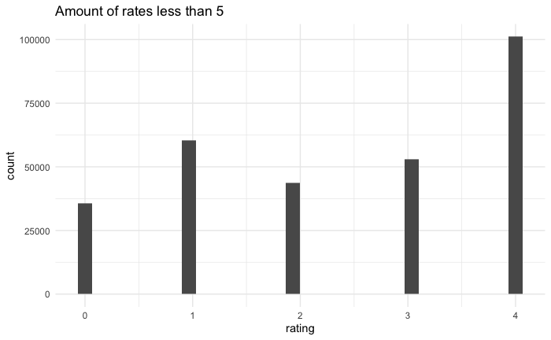

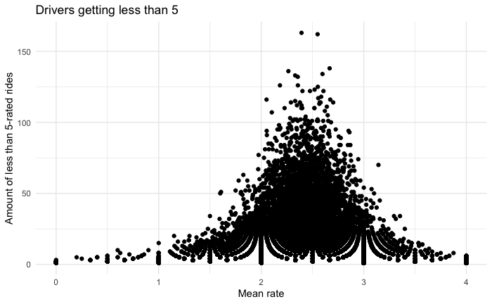

This graph shows that some drivers get a lot of non-5 rates, although their mean rate shifts righter being around 2 or 3. However, the cases when drivers systematically get 0 or 1 are insignificant.

All in all, small amount of bad rates (only 4.4%) is a positive sign for the ride-hailing market.

### 0.5.4 How often do unique riders use this service?

```
    rider_id             number             rating          distance
 Min.   :1.072e+15   Min.   :   1.000   Min.   :0.0      Min.   :      0
 1st Qu.:8.154e+17   1st Qu.:   2.000   1st Qu.:4.5      1st Qu.:   4542
 Median :1.153e+18   Median :   3.000   Median :5.0      Median :   6770
 Mean   :1.153e+18   Mean   :   7.544   Mean   :4.5      Mean   :   8345
 3rd Qu.:1.491e+18   3rd Qu.:   8.000   3rd Qu.:5.0      3rd Qu.:  10023
 Max.   :2.304e+18   Max.   :1180.000   Max.   :5.0      Max.   :1514684
 NA's   :1                              NA's   :373325   NA's   :71444
```

869596 unique riders are observed in this dataset. Although some of their mean ride distances are clear outliers, exceeding 1000 km.

Other than that, riders mean number of service use is around 8 rides within 3 months dataset. Although, we see that there are outliers like 1000 rides which means that some riders use service more than 7 times per day.